# PlayCovid

# 1 Define functions

```r
source(file = "CovFunctions.R", echo = FALSE)
```

```
## [1] "data.gov.uk <- function(AREA.TYPE = \"overview\", AREA.NAME = \"United Kingdom\")\n"
## [1] "lmDate <- function(ycol, aDF, maxrows = nrow(aDF), zerwt =  0, zerdays = NULL, power = 2, wDay = FALSE, xcol = date, vref = vrefDF):  log(y) ~ polynomial model \n"
## [1] "getcData <- function(cFile, maxlag = 20, mincount = 5); retrieve and process aggregate data"
```

## 1.1 constructs to ease plots

- log y axis (logy)
- vertical reference lines (vrefDF) for English restriction dates

```
##             x           label
## 1  2020-03-23       23/3 lock
## 2  2020-05-10       10/5 ease
## 3  2020-06-15       15/6 ease
## 4  2020-07-24  24/7 facemasks
## 5  2020-08-03       2/8 EOTHO
## 6  2020-09-14  14/9 rule of 6
## 7  2020-10-14 \n14/10 3 tiers
## 8  2020-11-05       5/11 lock
## 9  2020-12-02    2/12 3 tiers
## 10 2020-12-20   20/12 4 tiers
## 11 2021-01-05        5/1 lock
```

# 2 Get current UK data (UKDF)

If new, append current DateDeaths, PubDeaths, and SpecCases to aggregates saved in rds files

```
## 'data.frame':    413 obs. of  12 variables:
##  $ date         : Date, format: "2021-03-17" "2021-03-16" ...
##  $ area         : chr  "United Kingdom" "United Kingdom" "United Kingdom" "United Kingdom" ...
##  $ Tests        : int  NA NA 1573774 965127 437958 1402203 1614145 1554080 1374579 1529525 ...
##  $ PubCases     : int  5758 5294 5089 4618 5534 6609 6753 5926 5766 4712 ...
##  $ SpecCases    : int  NA NA 5945 4202 4201 5669 5886 6162 6341 6832 ...
##  $ cumSpecCases : int  NA NA 4272811 4266866 4262664 4258463 4252794 4246908 4240746 4234405 ...
##  $ Admits       : int  NA NA NA NA NA 465 539 566 575 574 ...
##  $ InPats       : int  NA NA 7218 7288 7356 7701 8044 8423 8998 9464 ...
##  $ MVBeds       : int  NA 968 1016 1049 1087 1110 1192 1236 1292 1356 ...
##  $ PubDeaths    : int  141 110 64 52 121 175 181 190 231 65 ...
##  $ DateDeaths   : int  NA NA 57 64 93 73 100 109 129 140 ...
##  $ cumDateDeaths: int  NA NA 125816 125759 125695 125602 125529 125429 125320 125191 ...
## [1] "2020-01-30 to 2021-03-17"
## [1] "Added deaths: 2021-03-17"
## [1] "Added cases: 2021-03-17"
## [1] "Added PubDeaths: 2021-03-17"
```

# 3 Models v. date

*lmDate arguments*  
1) (ycol) name of dependent variable in …  
2) (aDF) … a data frame.  
3) (maxrows) number of points in linear model (ndays = 42).

Optionally specify zero-weight for last zerwt dates and/or specified dates (zerdays).

- For some dependent variables coronavirus.data.gov.uk marks last five as “incomplete” suggesting zerwt = 5.
- For some dependent variables Xmas day and NY day are “different” suggesting zerdays = c(“2020-12-25”, “2021-01-01”).

*Output*  
Fit linear model to last maxrows dates, respecting any specified zero-weights. Model is quadratic in date, ln(y) ~ poly(date, 2), with optional day-of-week factor (wDay = TRUE).

- Plot all data with loess(span = 0.1) smoother, omitting zero-weighted data from loess.
- Plot linear model data points and fit line. If model includes day-of-week then, to clarify underlying trend, additionally plot fit line in which day-of-week always = Sunday.
- Print text containing (differences calculated without any day-of-week factor):
  - latest fitted value, y<sub>1</sub>;
  - latest first difference, ln(y<sub>1</sub>) - ln(y<sub>2</sub>); expressed as doubling/halving time of y;
  - latest second difference, [ln(y<sub>1</sub>) - ln(y<sub>2</sub>)] - [ln(y<sub>2</sub>) - ln(y<sub>3</sub>)]; expressed as doubling/halving time of first difference.
- Plot linear model residuals v. date.
- Print linear model descriptive statistics. (*NB* Model is intended as descriptive, not predictive. P-values and hypothesis test statistics are not easily interpretable.)

## 3.1 Tests

Linear model over 9 weeks.

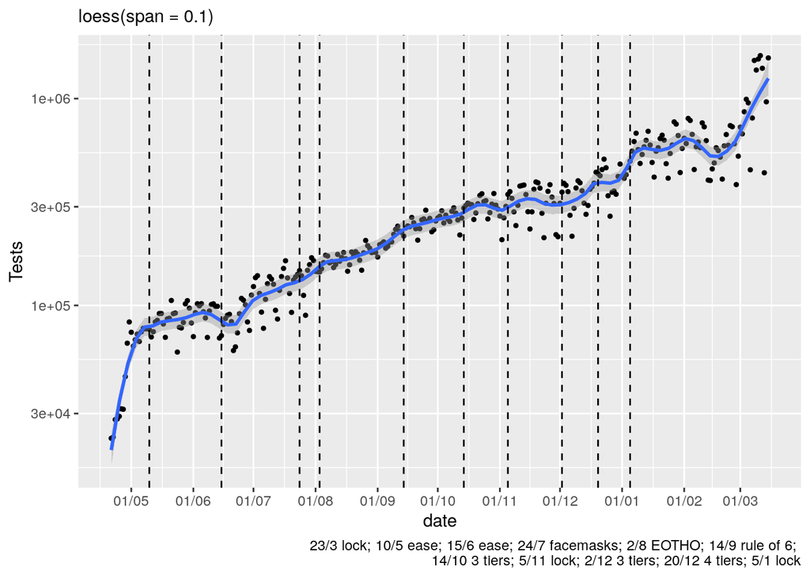

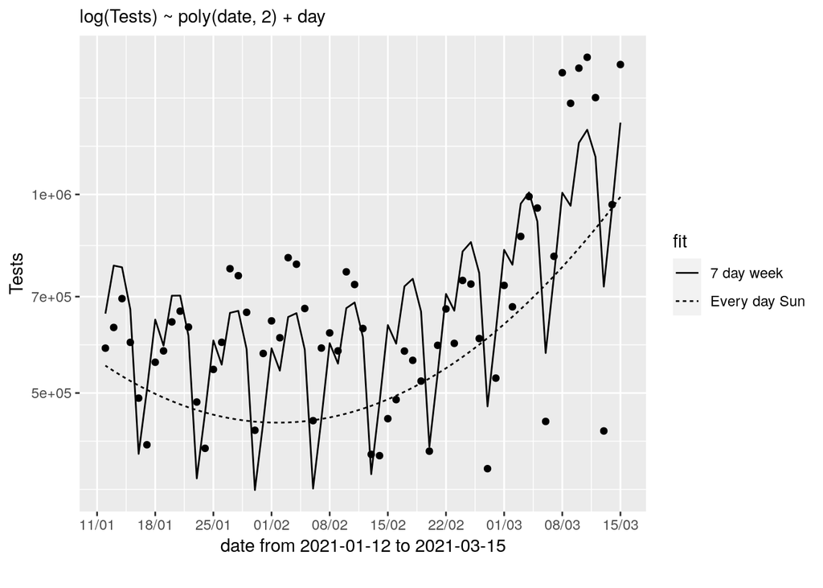

```
## At 15/03 fit = 1284911.5 with doubling time = 18.4 days. That time halving in 20.4 days
```

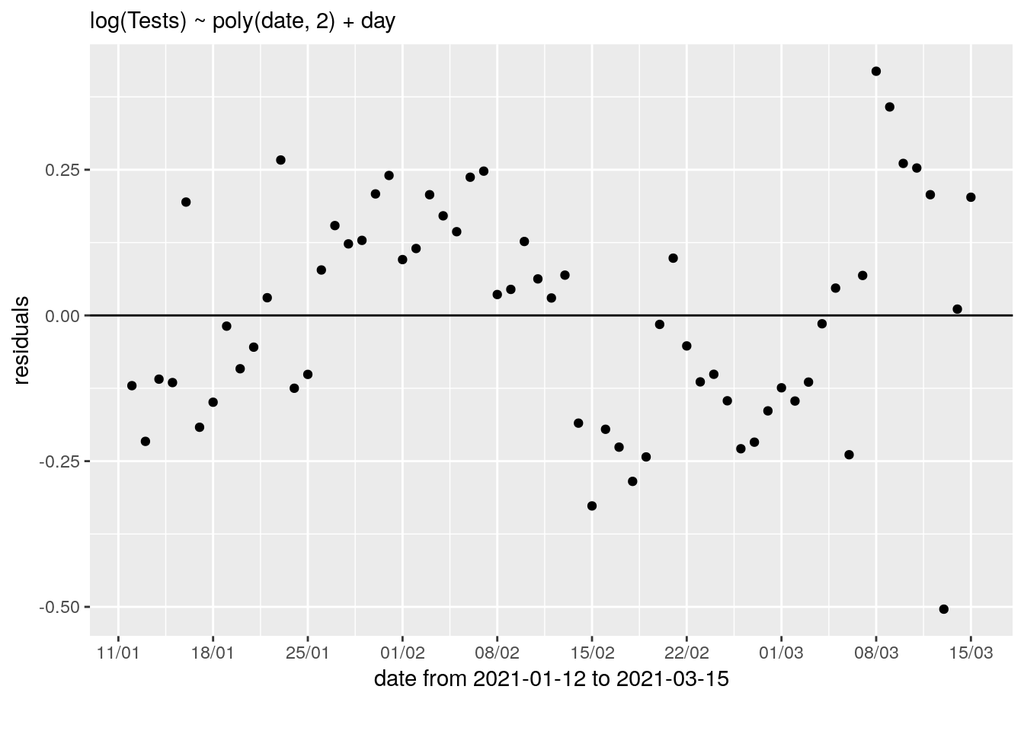

```
## Analysis of Variance Table
##
## Response: log(Tests)
##               Df Sum Sq Mean Sq F value    Pr(>F)
## poly(date, 2)  2 2.8794 1.43970  36.013 1.154e-10 ***
## day            6 2.6371 0.43952  10.994 5.682e-08 ***
## Residuals     54 2.1588 0.03998
## ---
## Signif. codes:  0 '***' 0.001 '**' 0.01 '*' 0.05 '.' 0.1 ' ' 1
##
## Call:
## lm(formula = as.formula(aform), data = aDF, weights = weights)
##
## Residuals:
##      Min       1Q   Median       3Q      Max
## -0.50396 -0.13569  0.01083  0.13621  0.41896
##
## Coefficients:
##                Estimate Std. Error t value Pr(>|t|)
## (Intercept)    13.22067    0.06671 198.193  < 2e-16 ***
## poly(date, 2)1  1.37118    0.20116   6.816 8.19e-09 ***
## poly(date, 2)2  1.08611    0.19996   5.432 1.36e-06 ***
## dayMon          0.25929    0.09427   2.751 0.008078 **
## dayTue          0.18157    0.09451   1.921 0.060006 .
## dayWed          0.36809    0.09442   3.898 0.000270 ***
## dayThu          0.37985    0.09435   4.026 0.000178 ***
## dayFri          0.24994    0.09430   2.651 0.010520 *
## daySat         -0.23854    0.09426  -2.530 0.014338 *
## ---
## Signif. codes:  0 '***' 0.001 '**' 0.01 '*' 0.05 '.' 0.1 ' ' 1
##
## Residual standard error: 0.1999 on 54 degrees of freedom
## Multiple R-squared:  0.7187, Adjusted R-squared:  0.6771
## F-statistic: 17.25 on 8 and 54 DF,  p-value: 2.102e-12
```

```r
with(lmDate(Tests, UKDF, 63, wDay = TRUE),{
print(lplot + logy)
print(xyplot + logy )
cat(tailstr, "\n\n")
print(resplot)
print(anova(lm))
print(summary(lm))   })
```

## 3.2 Cases by Specimen Date

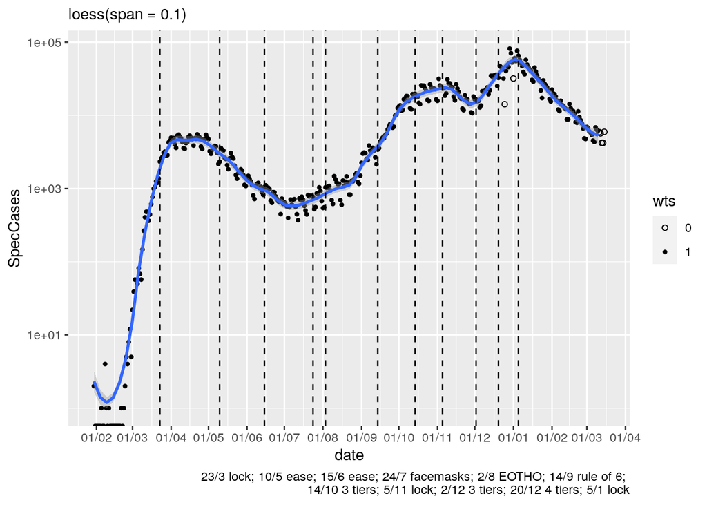

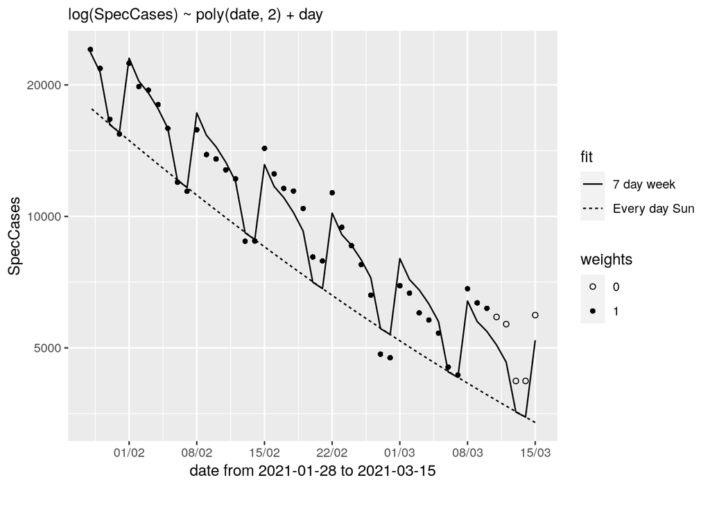

```
## At 15/03 fit = 5205.5 with halving time = 24.2 days. That time doubling in 86.2 days
```

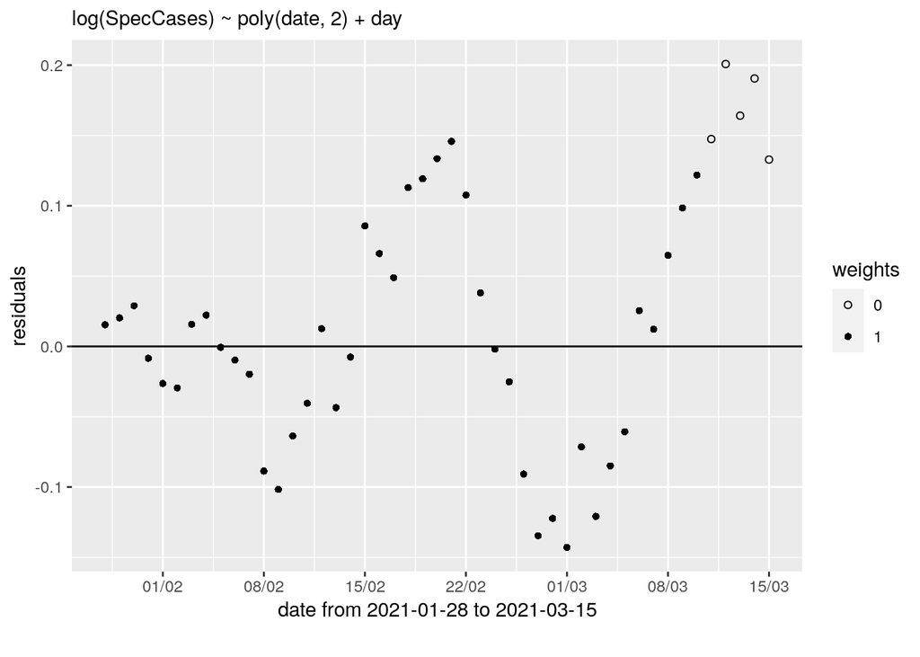

```
## Analysis of Variance Table
##
## Response: log(SpecCases)
##               Df Sum Sq Mean Sq F value    Pr(>F)
## poly(date, 2)  2 8.0664  4.0332 540.992 < 2.2e-16 ***
## day            6 1.0679  0.1780  23.873 1.085e-10 ***
## Residuals     33 0.2460  0.0075
## ---
## Signif. codes:  0 '***' 0.001 '**' 0.01 '*' 0.05 '.' 0.1 ' ' 1
##
## Call:
## lm(formula = as.formula(aform), data = aDF, weights = weights)
##
## Weighted Residuals:
##      Min       1Q   Median       3Q      Max
## -0.14298 -0.04197  0.00000  0.03350  0.14578
##
## Coefficients:
##                 Estimate Std. Error t value Pr(>|t|)
## (Intercept)     8.896380   0.035684 249.307  < 2e-16 ***
## poly(date, 2)1 -3.353453   0.113880 -29.447  < 2e-16 ***
## poly(date, 2)2  0.186975   0.114453   1.634    0.112
## dayMon          0.433283   0.049863   8.689 4.82e-10 ***
## dayTue          0.355565   0.049902   7.125 3.67e-08 ***
## dayWed          0.333809   0.049971   6.680 1.32e-07 ***
## dayThu          0.292325   0.049971   5.850 1.50e-06 ***
## dayFri          0.230991   0.049902   4.629 5.48e-05 ***
## daySat         -0.002702   0.049863  -0.054    0.957
## ---
## Signif. codes:  0 '***' 0.001 '**' 0.01 '*' 0.05 '.' 0.1 ' ' 1
##
## Residual standard error: 0.08634 on 33 degrees of freedom
## Multiple R-squared:  0.9738, Adjusted R-squared:  0.9674
## F-statistic: 153.2 on 8 and 33 DF,  p-value: < 2.2e-16
##
##   SpecCases       date   fitted     dfit.dx    d2fit.dx2
## 3      5945 2021-03-15 3375.151 -0.02859829 0.0003316638
## 4      4202 2021-03-14 3473.068 -0.02892995           NA
## 5      4201 2021-03-13 3575.011          NA           NA
```

```r
with(lmDate(SpecCases, UKDF, 5 + ndays, zerwt = 5, zerdays = c("2020-12-25", "2021-01-01"), wDay = TRUE),{
print(lplot + logy)
print(xyplot + logy )
cat(tailstr, "\n\n")
print(resplot)
print(anova(lm))
print(summary(lm))
print(diffs)  })
```

## 3.3 Cases by Publish Date

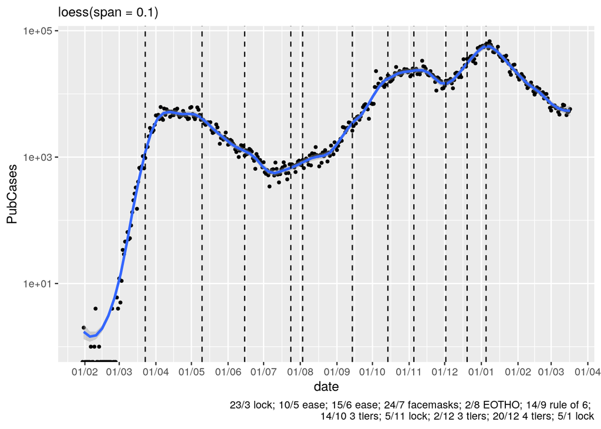

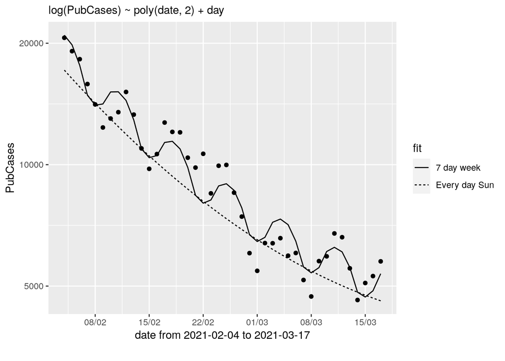

```
## At 17/03 fit = 5366.5 with halving time = 44.4 days. That time doubling in 18.9 days
```

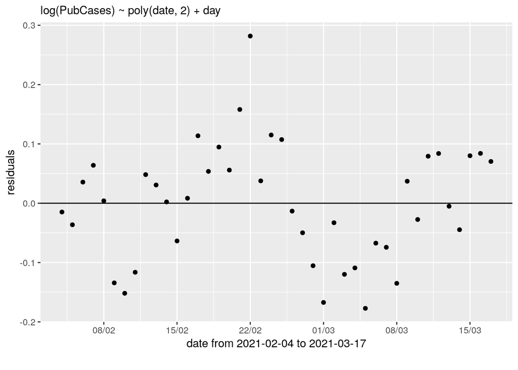

```
## Analysis of Variance Table
##
## Response: log(PubCases)
##               Df Sum Sq Mean Sq  F value    Pr(>F)
## poly(date, 2)  2 6.7196  3.3598 282.8015 < 2.2e-16 ***
## day            6 0.2840  0.0473   3.9839  0.004164 **
## Residuals     33 0.3921  0.0119
## ---
## Signif. codes:  0 '***' 0.001 '**' 0.01 '*' 0.05 '.' 0.1 ' ' 1
##
## Call:
## lm(formula = as.formula(aform), data = aDF, weights = weights)
##
## Residuals:
##       Min        1Q    Median        3Q       Max
## -0.177199 -0.066379  0.003132  0.068798  0.281843
##
## Coefficients:
##                Estimate Std. Error t value Pr(>|t|)
## (Intercept)     8.97871    0.04450 201.764  < 2e-16 ***
## poly(date, 2)1 -2.52337    0.11051 -22.833  < 2e-16 ***
## poly(date, 2)2  0.35134    0.10904   3.222  0.00286 **
## dayMon         -0.01031    0.06295  -0.164  0.87093
## dayTue          0.04166    0.06299   0.661  0.51297
## dayWed          0.15489    0.06308   2.455  0.01951 *
## dayThu          0.19942    0.06308   3.161  0.00336 **
## dayFri          0.19301    0.06299   3.064  0.00433 **
## daySat          0.12332    0.06295   1.959  0.05859 .
## ---
## Signif. codes:  0 '***' 0.001 '**' 0.01 '*' 0.05 '.' 0.1 ' ' 1
##
## Residual standard error: 0.109 on 33 degrees of freedom
## Multiple R-squared:  0.947,  Adjusted R-squared:  0.9341
## F-statistic: 73.69 on 8 and 33 DF,  p-value: < 2.2e-16
##
##   PubCases       date   fitted     dfit.dx    d2fit.dx2
## 1     5758 2021-03-17 4596.465 -0.01560687 0.0008258223
## 2     5294 2021-03-16 4668.764 -0.01643270           NA
## 3     5089 2021-03-15 4746.119          NA           NA
```

```r
with(lmDate( PubCases, UKDF, ndays, wDay = TRUE),{
print(lplot + logy)
print(xyplot + logy )
cat(tailstr, "\n\n")
print(resplot)
print(anova(lm))
print(summary(lm))
print(diffs)})
```

## 3.4 Patients admitted to hospital

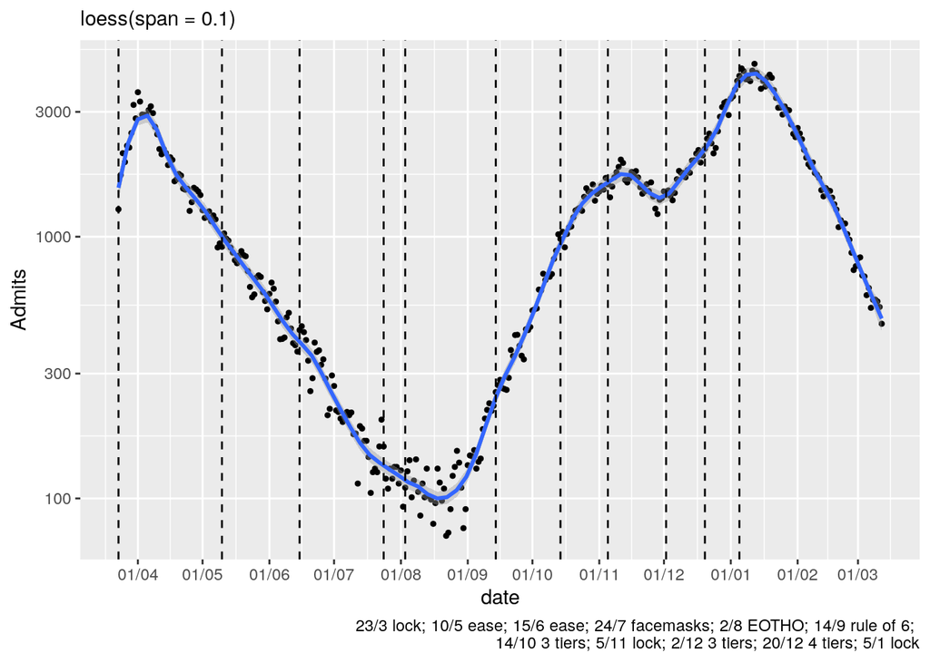

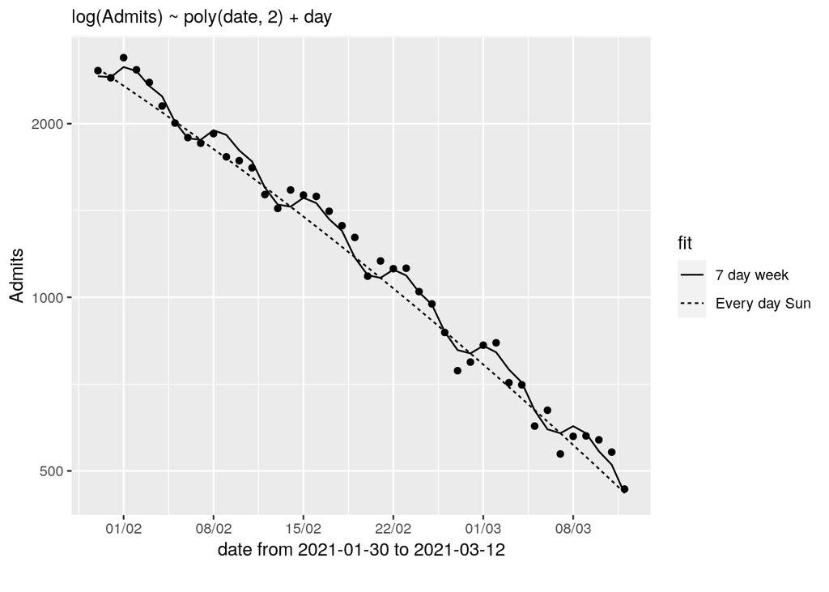

```
## At 12/03 fit = 457.2 with halving time = 14.3 days. That time halving in 69.0 days
```

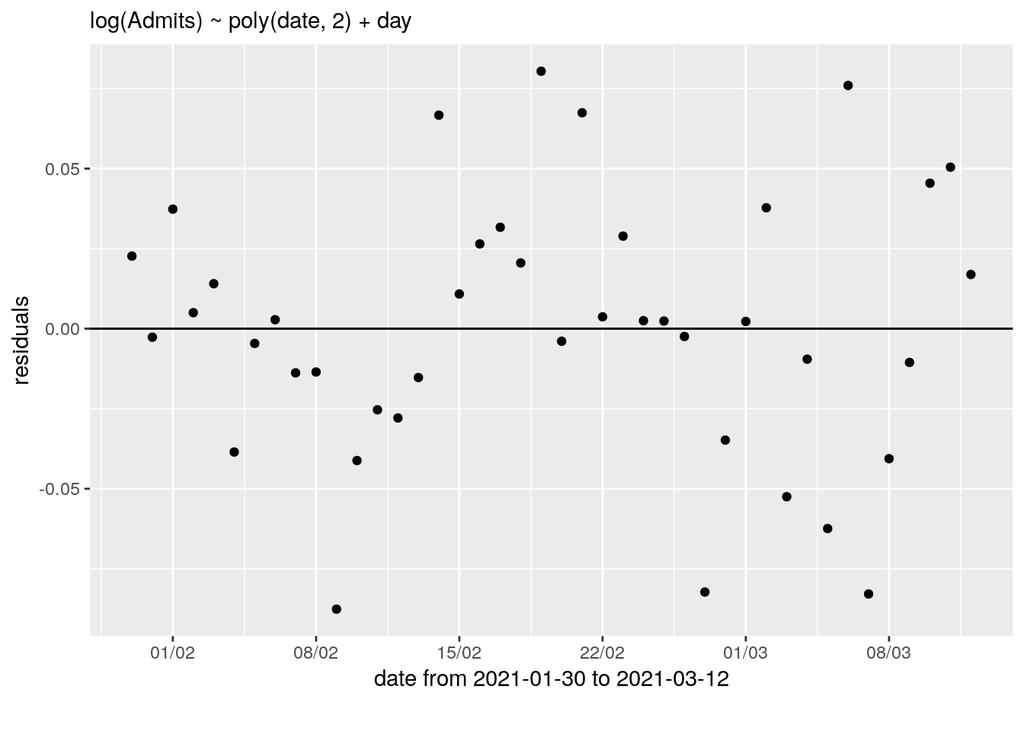

```
## Analysis of Variance Table
##
## Response: log(Admits)
##               Df  Sum Sq Mean Sq   F value    Pr(>F)
## poly(date, 2)  2 10.4544  5.2272 2496.5700 < 2.2e-16 ***
## day            6  0.0835  0.0139    6.6488 0.0001116 ***
## Residuals     33  0.0691  0.0021
## ---
## Signif. codes:  0 '***' 0.001 '**' 0.01 '*' 0.05 '.' 0.1 ' ' 1
##
## Call:
## lm(formula = as.formula(aform), data = aDF, weights = weights)
##
## Residuals:
##       Min        1Q    Median        3Q       Max
## -0.087614 -0.022819  0.002325  0.025525  0.080423
##
## Coefficients:
##                Estimate Std. Error t value Pr(>|t|)
## (Intercept)     7.02191    0.01872 375.147  < 2e-16 ***
## poly(date, 2)1 -3.24558    0.04639 -69.958  < 2e-16 ***
## poly(date, 2)2 -0.14906    0.04577  -3.256  0.00261 **
## dayMon          0.07502    0.02643   2.839  0.00769 **
## dayTue          0.09397    0.02644   3.553  0.00117 **
## dayWed          0.06983    0.02648   2.637  0.01265 *
## dayThu          0.06391    0.02652   2.410  0.02170 *
## dayFri         -0.00191    0.02658  -0.072  0.94315
## daySat         -0.03092    0.02643  -1.170  0.25038
## ---
## Signif. codes:  0 '***' 0.001 '**' 0.01 '*' 0.05 '.' 0.1 ' ' 1
##
## Residual standard error: 0.04576 on 33 degrees of freedom
## Multiple R-squared:  0.9935, Adjusted R-squared:  0.9919
## F-statistic: 629.1 on 8 and 33 DF,  p-value: < 2.2e-16
```

```r
with(lmDate(Admits, UKDF, ndays, wDay = TRUE),{
print(lplot + logy)
print(xyplot + logy )
cat(tailstr, "\n\n")
print(resplot)
print(anova(lm))
print(summary(lm)) })
```

## 3.5 Patients in hospital

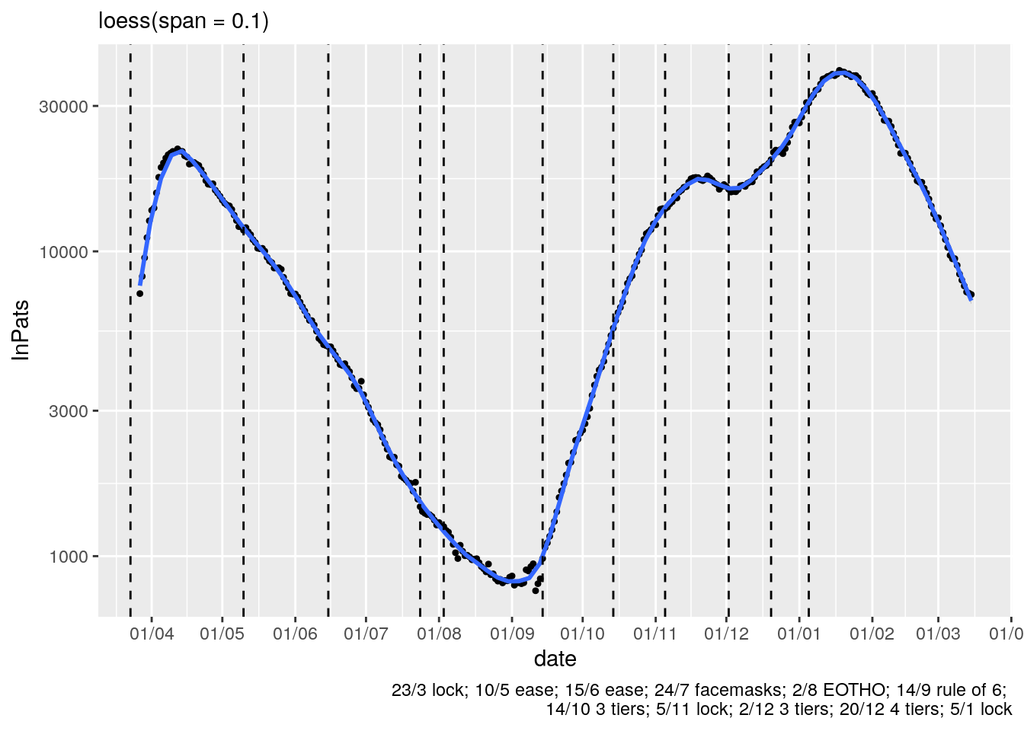

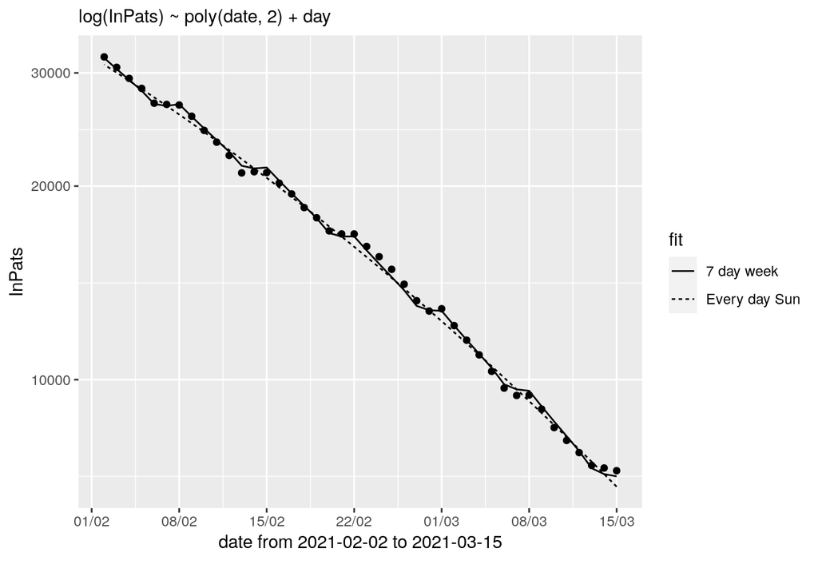

```
## At 15/03 fit = 7074.0 with halving time = 15.4 days. That time halving in 55.5 days
```

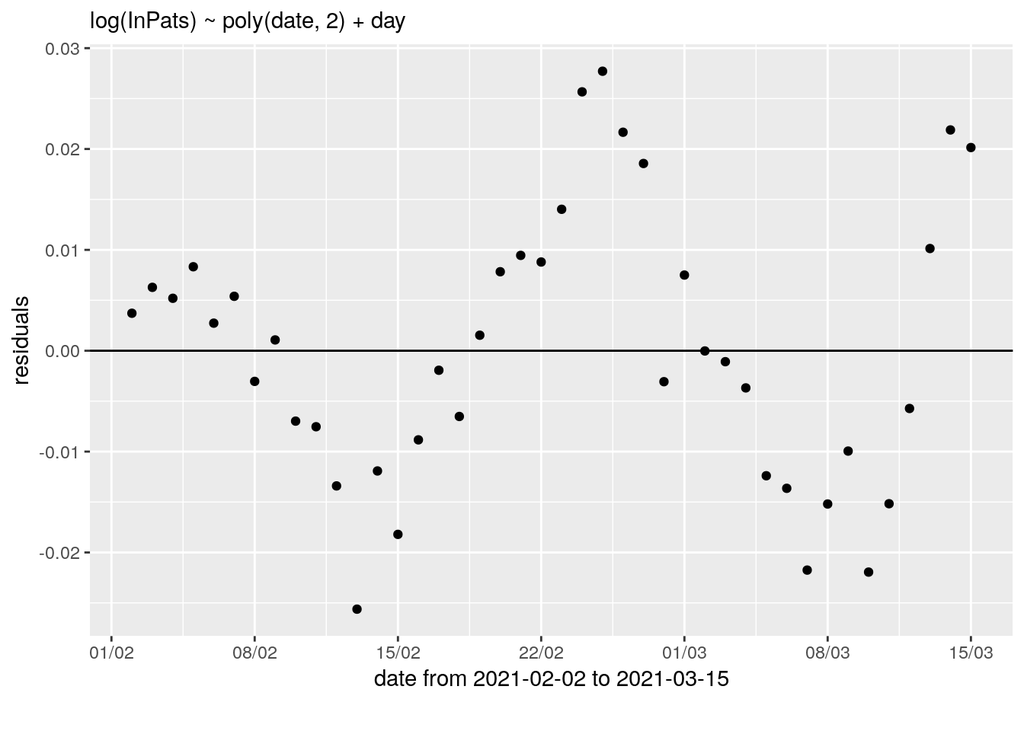

```
## Analysis of Variance Table
##
## Response: log(InPats)
##               Df Sum Sq Mean Sq  F value    Pr(>F)
## poly(date, 2)  2 8.4208  4.2104 18880.57 < 2.2e-16 ***
## day            6 0.0143  0.0024    10.68 1.386e-06 ***
## Residuals     33 0.0074  0.0002
## ---
## Signif. codes:  0 '***' 0.001 '**' 0.01 '*' 0.05 '.' 0.1 ' ' 1
##
## Call:
## lm(formula = as.formula(aform), data = aDF, weights = weights)
##
## Residuals:
##        Min         1Q     Median         3Q        Max
## -0.0256223 -0.0096711 -0.0005552  0.0082027  0.0277101
##
## Coefficients:
##                 Estimate Std. Error  t value Pr(>|t|)
## (Intercept)     9.638236   0.006109 1577.802  < 2e-16 ***
## poly(date, 2)1 -2.895933   0.015141 -191.267  < 2e-16 ***
## poly(date, 2)2 -0.172306   0.014938  -11.534 4.04e-13 ***
## dayMon          0.037059   0.008624    4.297 0.000144 ***
## dayTue          0.023856   0.008676    2.750 0.009603 **
## dayWed          0.012759   0.008656    1.474 0.149959
## dayThu          0.003287   0.008641    0.380 0.706081
## dayFri         -0.005980   0.008631   -0.693 0.493206
## daySat         -0.023517   0.008624   -2.727 0.010157 *
## ---
## Signif. codes:  0 '***' 0.001 '**' 0.01 '*' 0.05 '.' 0.1 ' ' 1
##
## Residual standard error: 0.01493 on 33 degrees of freedom
## Multiple R-squared:  0.9991, Adjusted R-squared:  0.9989
## F-statistic:  4728 on 8 and 33 DF,  p-value: < 2.2e-16
```

```r
with(lmDate(InPats, UKDF, ndays, wDay = TRUE),{
print(lplot + logy)
print(xyplot + logy )
cat(tailstr, "\n\n")
print(resplot)
print(anova(lm))
print(summary(lm)) })
```

## 3.6 Patients in mechanical ventilation beds

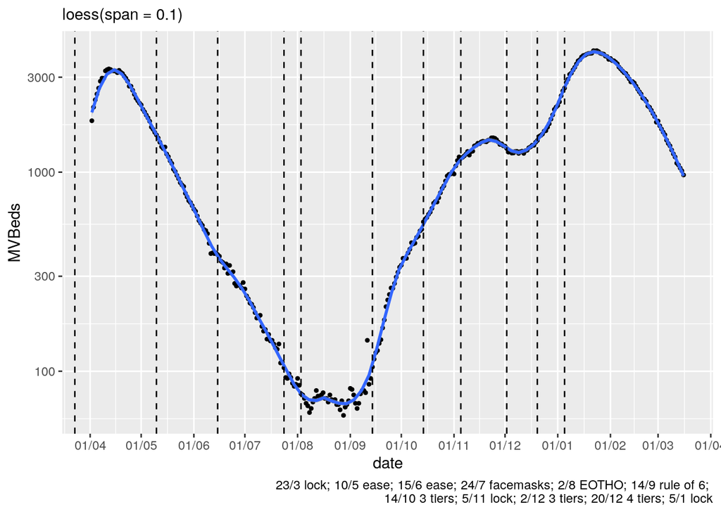

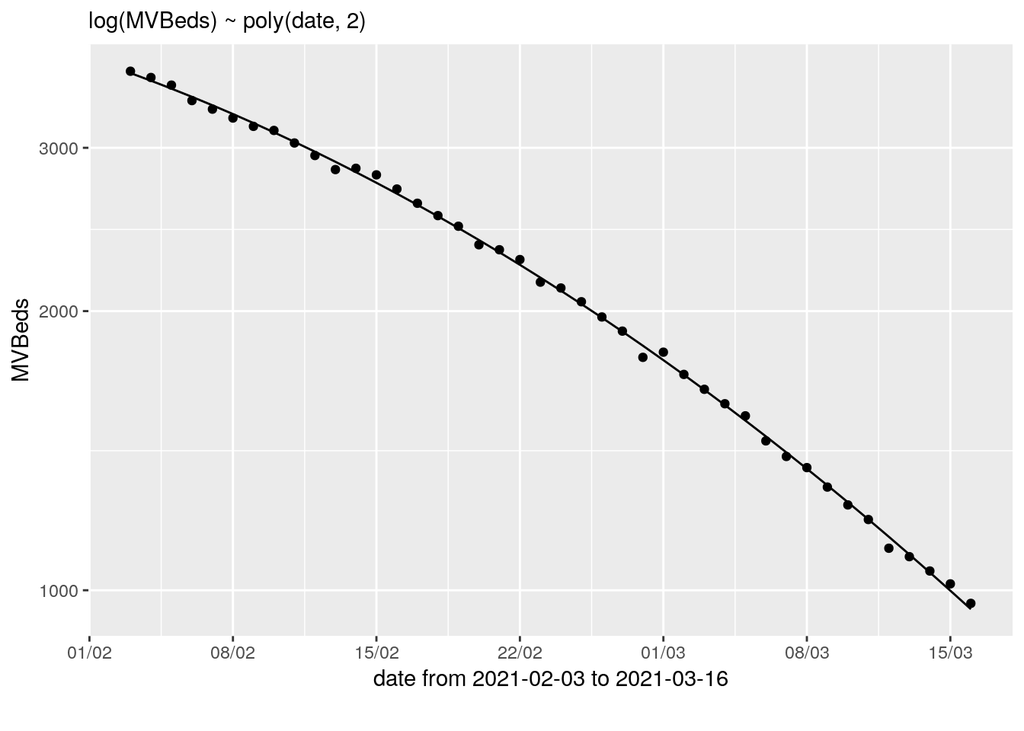

```
## At 16/03 fit = 954.2 with halving time = 15.1 days. That time halving in 34.1 days
```

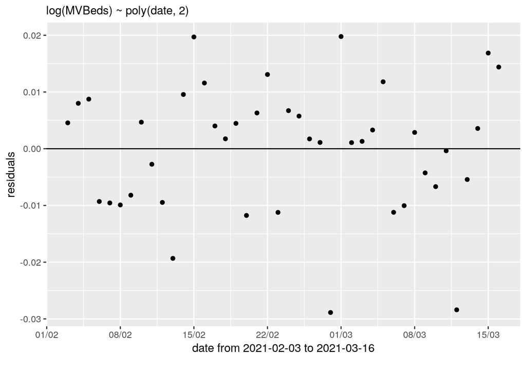

```
## Analysis of Variance Table
##
## Response: log(MVBeds)
##               Df Sum Sq Mean Sq F value    Pr(>F)
## poly(date, 2)  2 6.5854  3.2927   24584 < 2.2e-16 ***
## Residuals     39 0.0052  0.0001
## ---
## Signif. codes:  0 '***' 0.001 '**' 0.01 '*' 0.05 '.' 0.1 ' ' 1
##
## Call:
## lm(formula = as.formula(aform), data = aDF, weights = weights)
##
## Residuals:
##       Min        1Q    Median        3Q       Max
## -0.028871 -0.009024  0.001739  0.006611  0.019777
##
## Coefficients:
##                 Estimate Std. Error t value Pr(>|t|)
## (Intercept)     7.618371   0.001786 4266.16   <2e-16 ***
## poly(date, 2)1 -2.550163   0.011573 -220.35   <2e-16 ***
## poly(date, 2)2 -0.286451   0.011573  -24.75   <2e-16 ***
## ---
## Signif. codes:  0 '***' 0.001 '**' 0.01 '*' 0.05 '.' 0.1 ' ' 1
##
## Residual standard error: 0.01157 on 39 degrees of freedom
## Multiple R-squared:  0.9992, Adjusted R-squared:  0.9992
## F-statistic: 2.458e+04 on 2 and 39 DF,  p-value: < 2.2e-16
```

```r
with(lmDate(MVBeds, UKDF, ndays),{
print(lplot + logy)
print(xyplot + logy )
cat(tailstr, "\n\n")
print(resplot)
print(anova(lm))
print(summary(lm)) })
```

## 3.7 Deaths within 28 days of positive test by date of death

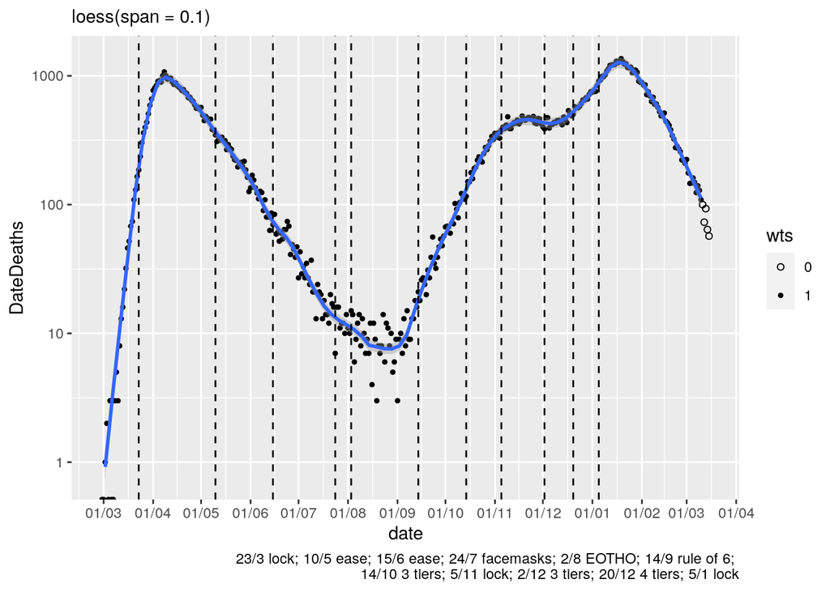

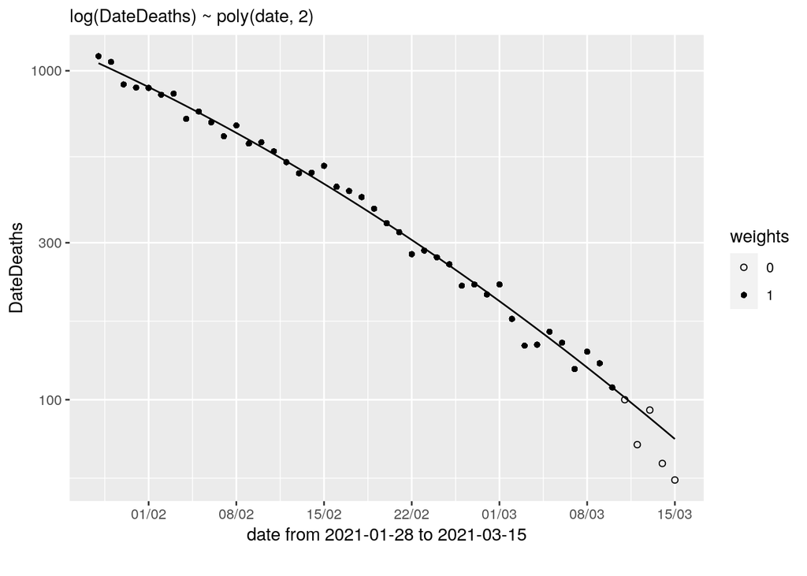

```
## At 15/03 fit = 75.9 with halving time = 9.4 days. That time halving in 50.2 days
```

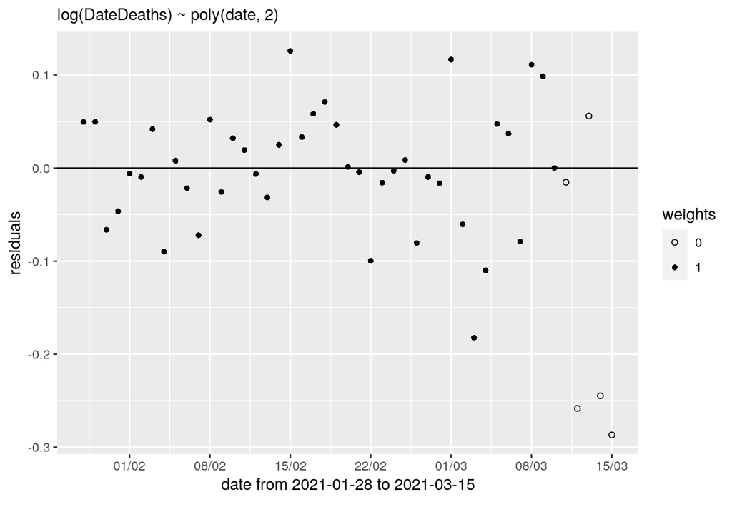

```
## Analysis of Variance Table
##
## Response: log(DateDeaths)
##               Df  Sum Sq Mean Sq F value    Pr(>F)
## poly(date, 2)  2 19.0061  9.5030  2145.4 < 2.2e-16 ***
## Residuals     39  0.1728  0.0044
## ---
## Signif. codes:  0 '***' 0.001 '**' 0.01 '*' 0.05 '.' 0.1 ' ' 1
##
## Call:
## lm(formula = as.formula(aform), data = aDF, weights = weights)
##
## Weighted Residuals:
##      Min       1Q   Median       3Q      Max
## -0.18235 -0.02351  0.00000  0.03951  0.12596
##
## Coefficients:
##                Estimate Std. Error t value Pr(>|t|)
## (Intercept)     5.77194    0.01102 523.770  < 2e-16 ***
## poly(date, 2)1 -5.31853    0.08678 -61.287  < 2e-16 ***
## poly(date, 2)2 -0.41386    0.08819  -4.693 3.29e-05 ***
## ---
## Signif. codes:  0 '***' 0.001 '**' 0.01 '*' 0.05 '.' 0.1 ' ' 1
##
## Residual standard error: 0.06655 on 39 degrees of freedom
## Multiple R-squared:  0.991,  Adjusted R-squared:  0.9905
## F-statistic:  2145 on 2 and 39 DF,  p-value: < 2.2e-16
```

```r
with(lmDate(DateDeaths, UKDF, 5 + ndays, zerwt = 5),{
print(lplot + logy)
print(xyplot + logy )
cat(tailstr, "\n\n")
print(resplot)
print(anova(lm))
print(summary(lm)) })
```

## 3.8 Deaths within 28 days of positive test by date of publication

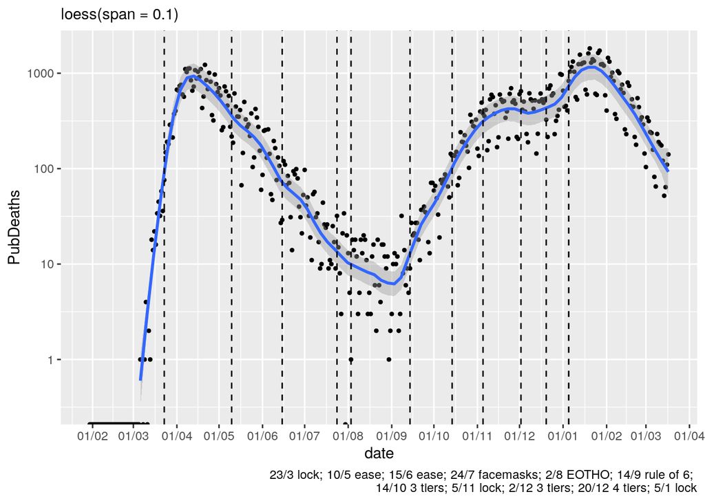

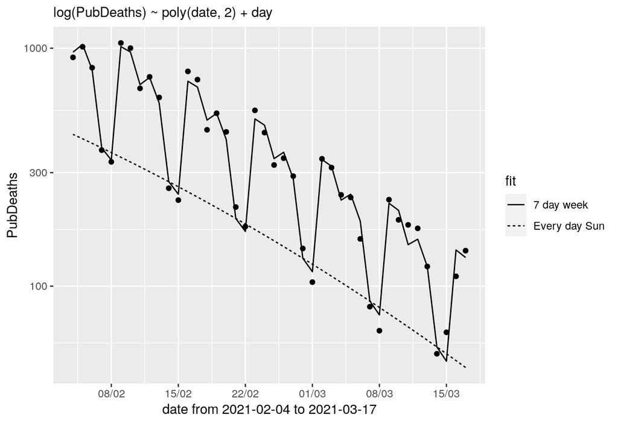

```
## At 17/03 fit = 132.0 with halving time = 10.4 days. That time halving in 56.2 days
```

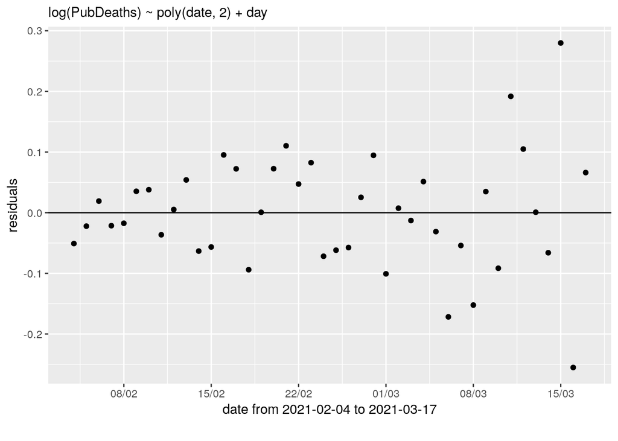

```
## Analysis of Variance Table
##
## Response: log(PubDeaths)
##               Df  Sum Sq Mean Sq F value    Pr(>F)
## poly(date, 2)  2 18.4990  9.2495   826.8 < 2.2e-16 ***
## day            6  8.3167  1.3861   123.9 < 2.2e-16 ***
## Residuals     33  0.3692  0.0112
## ---
## Signif. codes:  0 '***' 0.001 '**' 0.01 '*' 0.05 '.' 0.1 ' ' 1
##
## Call:
## lm(formula = as.formula(aform), data = aDF, weights = weights)
##
## Residuals:
##       Min        1Q    Median        3Q       Max
## -0.255268 -0.057256  0.000729  0.053339  0.279883
##
## Coefficients:
##                Estimate Std. Error t value Pr(>|t|)
## (Intercept)     5.02763    0.04318 116.426  < 2e-16 ***
## poly(date, 2)1 -4.32201    0.10724 -40.303  < 2e-16 ***
## poly(date, 2)2 -0.25348    0.10581  -2.396   0.0224 *
## dayMon         -0.07256    0.06108  -1.188   0.2433
## dayTue          1.07053    0.06113  17.513  < 2e-16 ***
## dayWed          1.06431    0.06121  17.387  < 2e-16 ***
## dayThu          0.79567    0.06121  12.998 1.56e-14 ***
## dayFri          0.91283    0.06113  14.933 3.07e-16 ***
## daySat          0.71257    0.06108  11.666 2.99e-13 ***
## ---
## Signif. codes:  0 '***' 0.001 '**' 0.01 '*' 0.05 '.' 0.1 ' ' 1
##
## Residual standard error: 0.1058 on 33 degrees of freedom
## Multiple R-squared:  0.9864, Adjusted R-squared:  0.9831
## F-statistic: 299.6 on 8 and 33 DF,  p-value: < 2.2e-16
```

```r
with(lmDate(PubDeaths,  UKDF, ndays, wDay = TRUE),{
print(lplot + logy)
print(xyplot + logy )
cat(tailstr, "\n\n")
print(resplot)
print(anova(lm))
print(summary(lm)) })
```

# 4 Worcestershire data

```
## 'data.frame':    440 obs. of  2 variables:
##  $ date     : Date, format: "2021-03-17" "2021-03-16" ...
##  $ SpecCases: int  NA 29 58 48 45 56 53 83 83 69 ...
## [1] "2020-01-03 to 2021-03-17"
```

## 4.1 Cases by Specimen Date (Worcs)

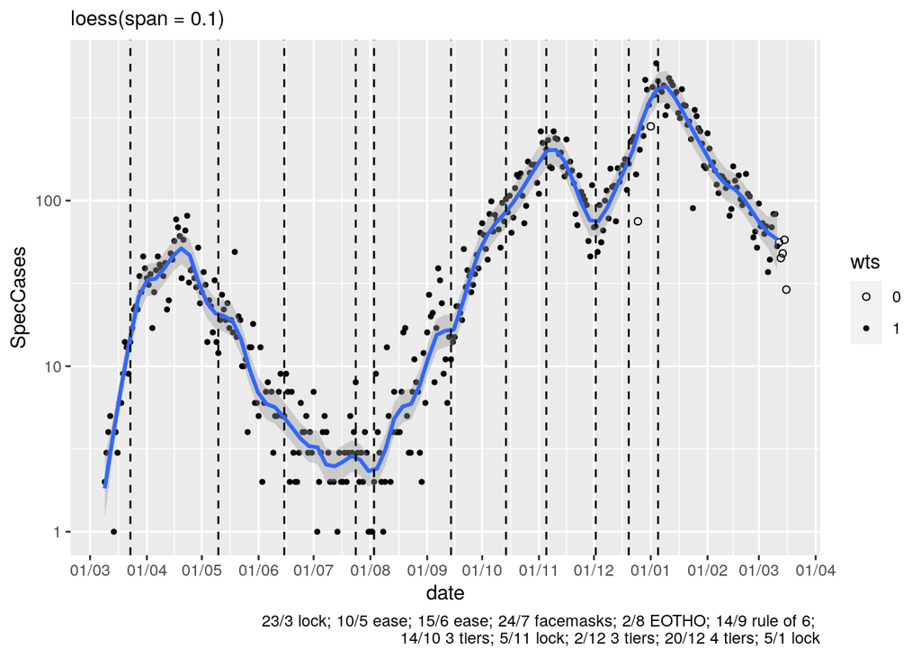

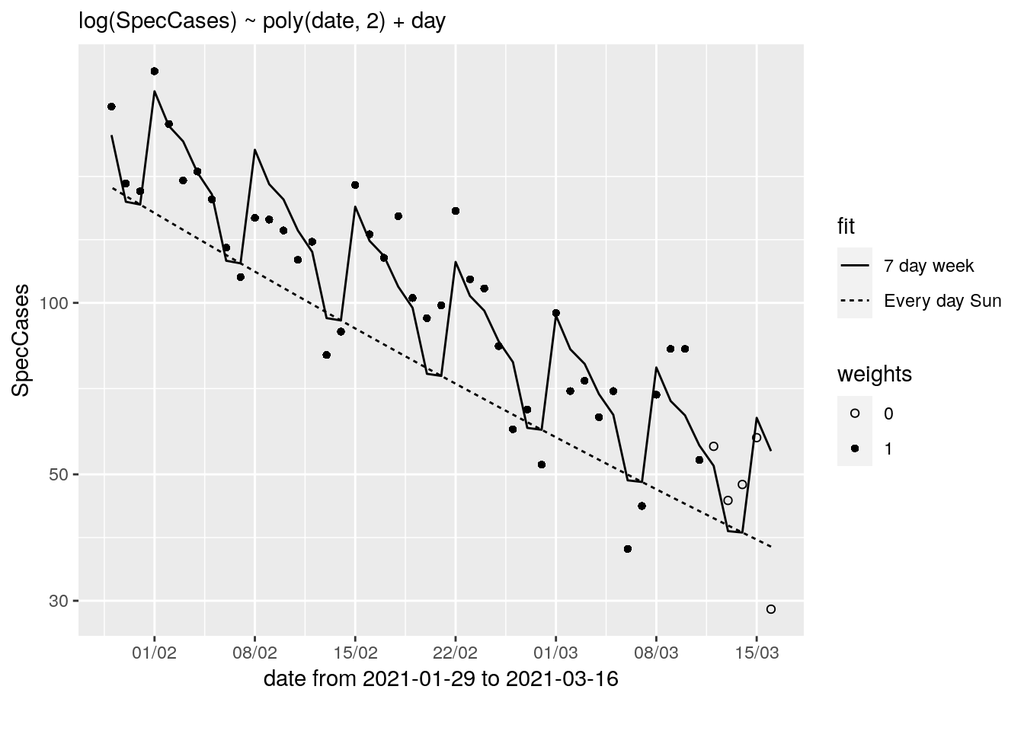

```
## At 16/03 fit = 54.9 with halving time = 24.3 days. That time doubling in 210.9 days
```

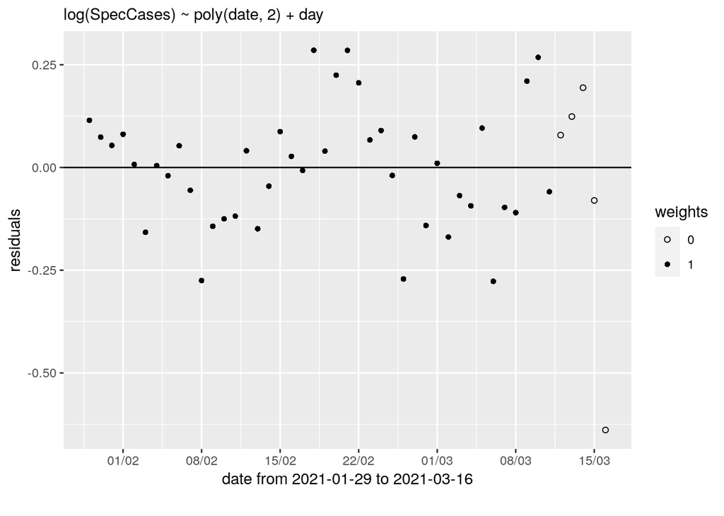

```
## Analysis of Variance Table
##
## Response: log(SpecCases)
##               Df Sum Sq Mean Sq  F value    Pr(>F)
## poly(date, 2)  2 5.7894 2.89472 111.3392 2.131e-15 ***
## day            6 1.3527 0.22545   8.6714 1.075e-05 ***
## Residuals     33 0.8580 0.02600
## ---
## Signif. codes:  0 '***' 0.001 '**' 0.01 '*' 0.05 '.' 0.1 ' ' 1
##
## Call:
## lm(formula = as.formula(aform), data = aDF, weights = weights)
##
## Weighted Residuals:
##      Min       1Q   Median       3Q      Max
## -0.27704 -0.09516  0.00000  0.07417  0.28528
##
## Coefficients:
##                Estimate Std. Error t value Pr(>|t|)
## (Intercept)     4.32232    0.06681  64.697  < 2e-16 ***
## poly(date, 2)1 -2.93471    0.21267 -13.800 2.93e-15 ***
## poly(date, 2)2  0.07623    0.21374   0.357 0.723617
## dayMon          0.49224    0.09312   5.286 7.93e-06 ***
## dayTue          0.38632    0.09319   4.146 0.000222 ***
## dayWed          0.35765    0.09330   3.833 0.000539 ***
## dayThu          0.26538    0.09348   2.839 0.007688 **
## dayFri          0.21182    0.09320   2.273 0.029679 *
## daySat         -0.02310    0.09312  -0.248 0.805618
## ---
## Signif. codes:  0 '***' 0.001 '**' 0.01 '*' 0.05 '.' 0.1 ' ' 1
##
## Residual standard error: 0.1612 on 33 degrees of freedom
## Multiple R-squared:  0.8928, Adjusted R-squared:  0.8668
## F-statistic: 34.34 on 8 and 33 DF,  p-value: 7.664e-14
```

```r
with(lmDate(SpecCases, subset(woDF, SpecCases > 0), 5 + ndays, zerwt = 5, zerdays = c("2020-12-25", "2021-01-01"), wDay = TRUE),{
print(lplot + logy)
print(xyplot + logy )
cat(tailstr, "\n\n")
print(resplot)
print(anova(lm))
print(summary(lm)) })
```

# 5 Wychavon data

```
## 'data.frame':    440 obs. of  2 variables:
##  $ date     : Date, format: "2021-03-17" "2021-03-16" ...
##  $ SpecCases: int  NA 5 8 4 16 9 5 13 13 6 ...
## [1] "2020-01-03 to 2021-03-17"
```

## 5.1 Cases by Specimen Date (Wych)

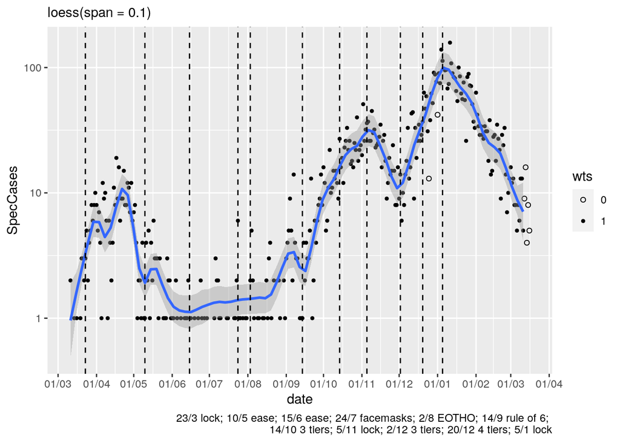

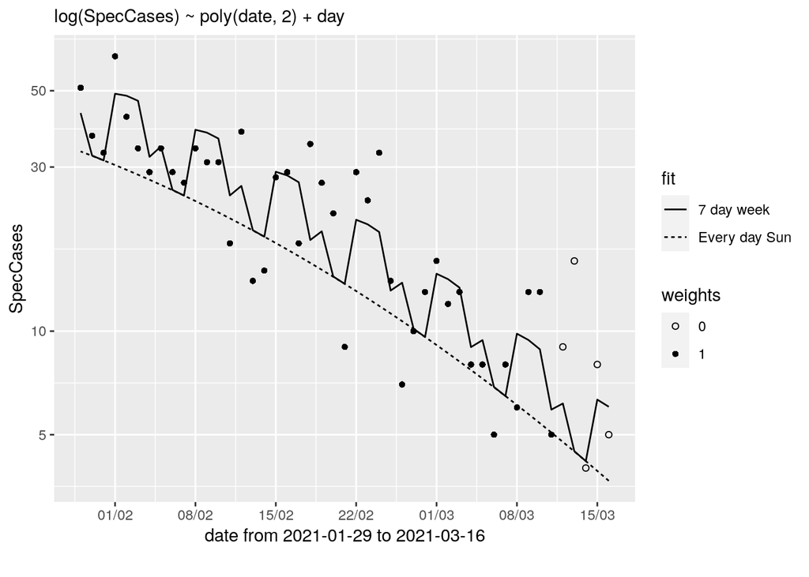

```
## At 16/03 fit =  6.0 with halving time = 10.5 days. That time halving in 40.6 days
```

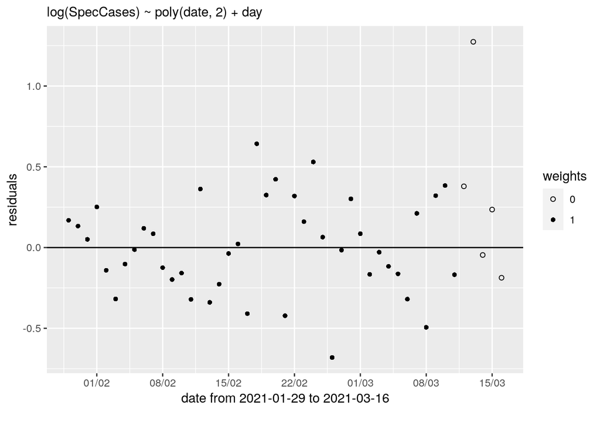

```
## Analysis of Variance Table
##
## Response: log(SpecCases)
##               Df  Sum Sq Mean Sq F value   Pr(>F)
## poly(date, 2)  2 12.4893  6.2446 58.8447 1.31e-11 ***
## day            6  1.8112  0.3019  2.8445  0.02411 *
## Residuals     33  3.5020  0.1061
## ---
## Signif. codes:  0 '***' 0.001 '**' 0.01 '*' 0.05 '.' 0.1 ' ' 1
##
## Call:
## lm(formula = as.formula(aform), data = aDF, weights = weights)
##
## Weighted Residuals:
##     Min      1Q  Median      3Q     Max
## -0.6807 -0.1644  0.0000  0.1646  0.6426
##
## Coefficients:
##                 Estimate Std. Error t value Pr(>|t|)
## (Intercept)     2.544101   0.134975  18.849  < 2e-16 ***
## poly(date, 2)1 -4.458112   0.429654 -10.376 6.37e-12 ***
## poly(date, 2)2 -0.460624   0.431814  -1.067   0.2938
## dayMon          0.477377   0.188126   2.538   0.0161 *
## dayTue          0.495936   0.188266   2.634   0.0127 *
## dayWed          0.494769   0.188504   2.625   0.0130 *
## dayThu          0.153346   0.188854   0.812   0.4226
## dayFri          0.257300   0.188291   1.366   0.1810
## daySat          0.001717   0.188129   0.009   0.9928
## ---
## Signif. codes:  0 '***' 0.001 '**' 0.01 '*' 0.05 '.' 0.1 ' ' 1
##
## Residual standard error: 0.3258 on 33 degrees of freedom
## Multiple R-squared:  0.8033, Adjusted R-squared:  0.7556
## F-statistic: 16.84 on 8 and 33 DF,  p-value: 1.269e-09
```

```r
with(lmDate(SpecCases, subset(wyDF, SpecCases >0),5 + ndays, zerwt = 5, zerdays = c("2020-12-25", "2021-01-01"), wDay = TRUE),{
print(lplot + logy)
print(xyplot + logy )
cat(tailstr, "\n\n")
print(resplot)
print(anova(lm))
print(summary(lm)) })
```